# Problem description

The single cell RNA Sequencing dataset used in the *[paper](https://www.science.org/doi/10.1126/science.abf1970)* from *Perez et. al.*, available at GEO accession number GSE174188 has a strong technical effect linked to the cohorts where the samples were processed. This processing cohort effect introduces unwanted variation that can obscure the biological signals of interest.To address this issue, we select a subset of healthy controls and evaluate the effectiveness of RUV methods (RUV2, RUVIII, RUV4) to normalize the data by removing the unwanted factors *W*, source of the unwanted variation. Additionally, we included a fourth approach for comparison: the direct Removal of the processing cohort effect, estimated using a linear model of the log-transformed data.

# Benchmarking tools

- PCA (Principal Component Analysis) plots: To visually inspect clustering patterns and check if samples separate by cohort or by biological conditions after normalization. The PCA is performed over the logCPM values of the 500 most variable genes.
- Silhouette coefficients: To measure how well-defined the processing cohort clusters are before and after normalization. In our case, lower or negative silhouette coefficients are desirable, as they indicate reduced clustering driven by a known technical factor (the processing cohort). The silhouette coefficients are computed using the first 10 PCs and the Manhattan distance.
- RLE (Relative Log Expression) plots: To observe differences in the gene expression of samples from different processing cohorts.
- p-value histograms (under no expected differential expression): To check if the normalization method induces a higher proportion of false positives. The p-values are computed using the Limma-Voom method to test for differential expression between 2 groups (mock treatment A vs mock treatment B) where no true differences are expected.

We demonstrate that the inclusion of pseudobulk pseudosamples (PBPS) in the RUVIII method outperforms other methods (including the direct removal of the Processing cohort effect) to reduce the unwanted variation in the normalized datasets.

# Analysis

## Files

The following files were generated in the Data wrangling vignette and contain the pseudobulk matrix and the pseudobulk pseudosamples.

```r
PBC <- readRDS("~/PBPS/Data/pblupusds2.rds")
PBPSC  <- readRDS("~/PBPS/Data/pbps10rep_ds2.rds")
```

## Negative control genes and high variable genes

The following analysis uses the *[negative control genes](https://www.worldscientific.com/doi/abs/10.1142/S0219720020400041)* proposed by *Deeke and Gagnon-Bartsch*. We remove from the negative control genes set the genes with a standardized variance higher than 1.8.

```r
hkGagnon <- read.csv(paste0(path,"/Genes_Gagnon.txt"), sep="")
hkGagnon <- unlist(hkGagnon)
filter.vst <- FindVariableFeatures(PBC$counts, selection.method = 'vst')
top_high_regvarg<-rownames(arrange(filter.vst,-variance))[1:500]
high_varg <- which(filter.vst[hkGagnon,]$variance.standardized>1.8)

gene.D <- data.frame(gene=rownames(PBC))
rownames(gene.D) <- gene.D$gene
hk.ind <- rownames(PBC) %in% hkGagnon[-high_varg]
```

## Assigning the mock treatment

We randomly assign a mock treatment with 2 levels to later test for differential expression.

```r
subs <- unique(PBC$samples$ind_cov)
set.seed(1)
treatment <- sample(c("A","B"),length(subs), replace=T)

PBC$samples <- PBC$samples %>% left_join(bind_cols(ind_cov = subs, fk.tr = treatment), by='ind_cov')
```

## Subsample

We have N = 37 assays from J = 29 subjects, the samples from processing cohort 4 come from a different laboratory, with the exception of the sample labelled as *control*, which was collected in the same laboratory than the samples from the first 3 processing cohorts. The mock treatments were assigned as follows:

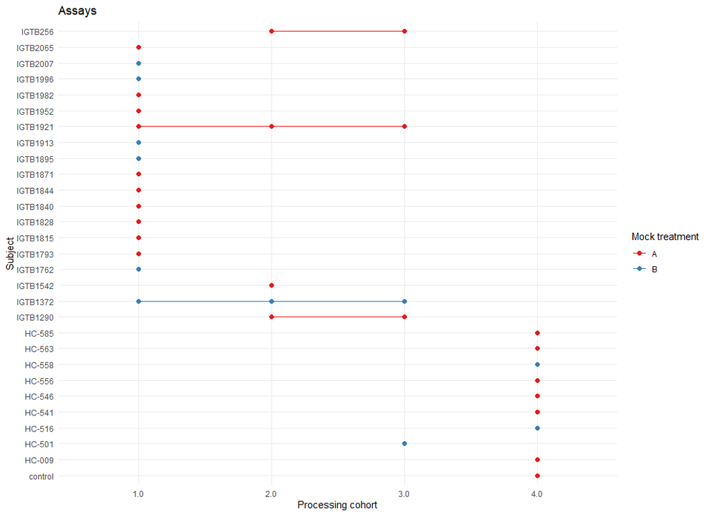

It is a standard in pseudobulk studies to analyze the samples from different cell types separately. Therefore we will review the results for 8 cell types present in the data.

## Unwanted variation

Before using any normalization method, we observe a strong effect associated with the processing cohort in all cell types. The differences between the RLE across samples is not high, but the silhouette coefficients are, as well as the clustering effects in the first 2 principal components. Most of the p-values histograms are roughly homogeneous, indicating no confounding effect between the processing cohorts and the mock treatment.

### B

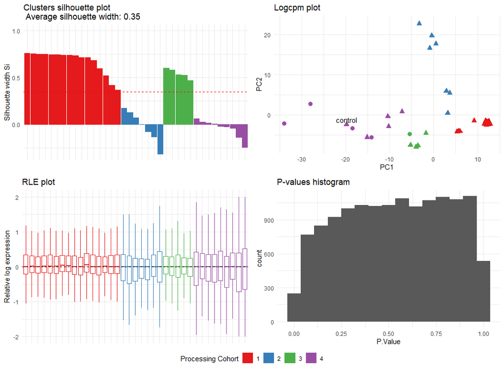

### NK

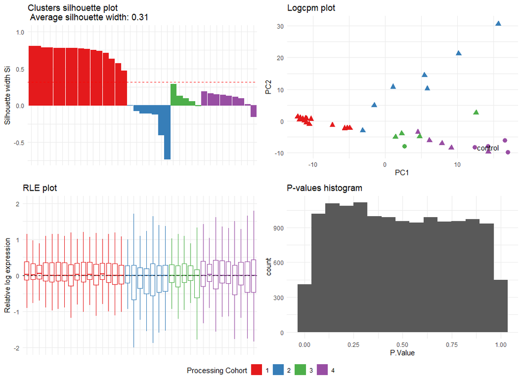

### T4

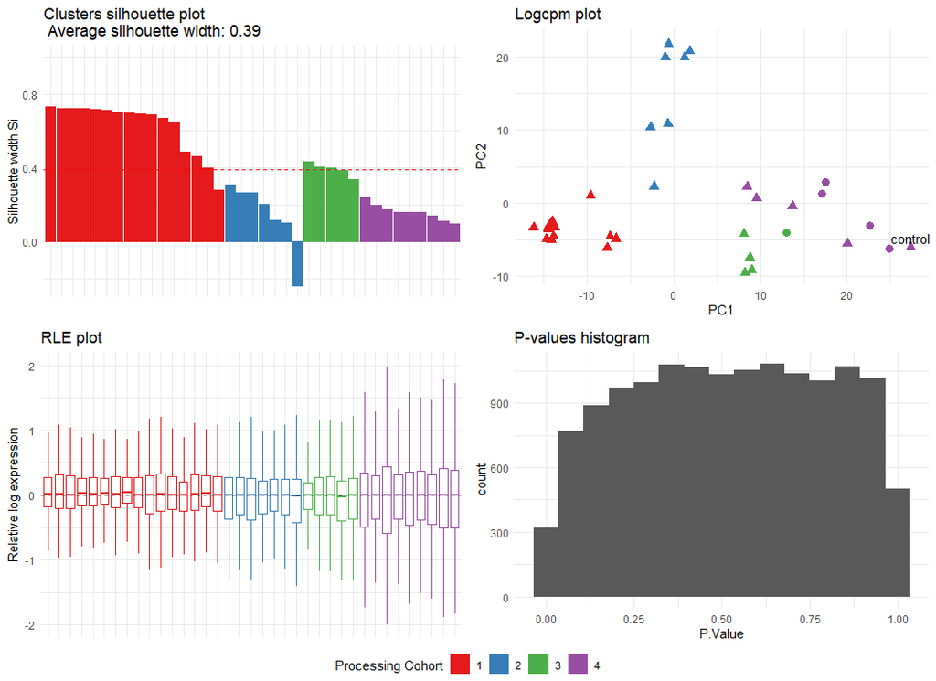

### T8

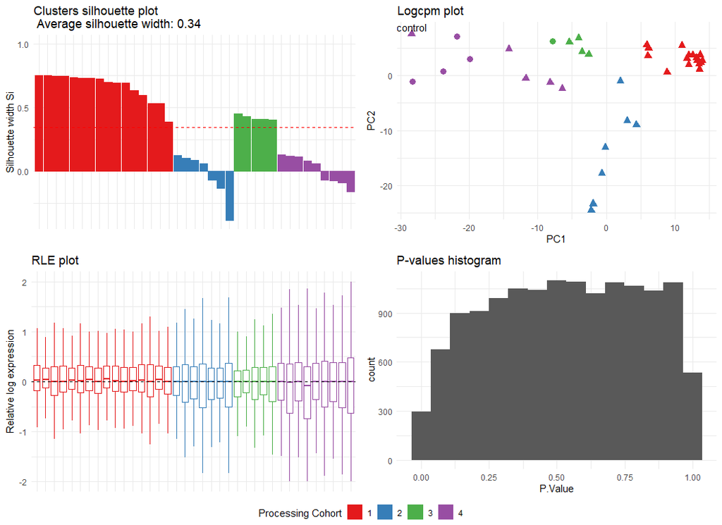

### cDC

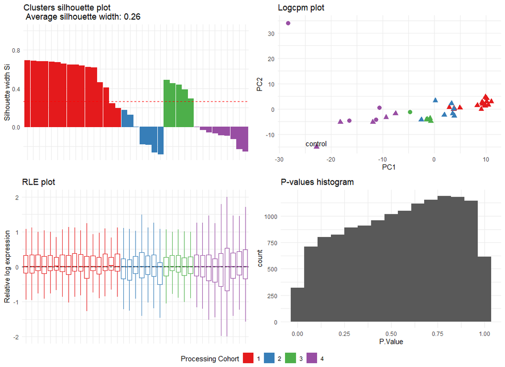

### cM

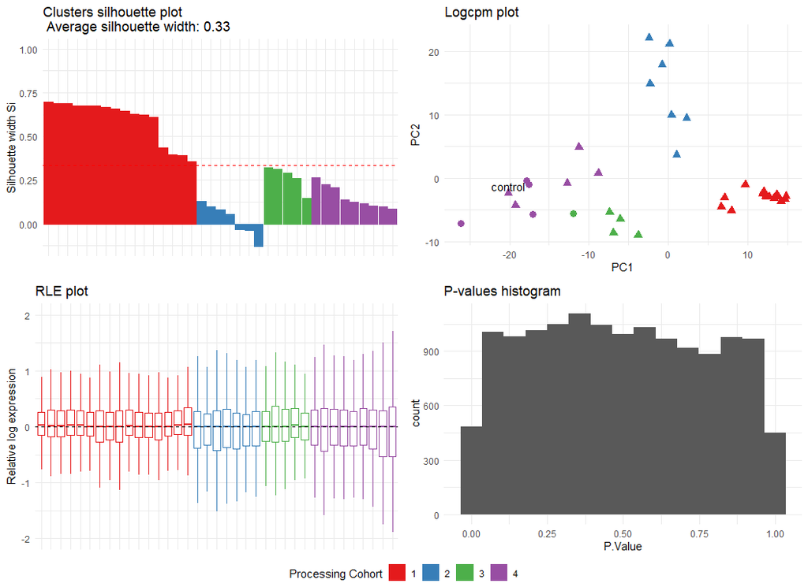

### ncM

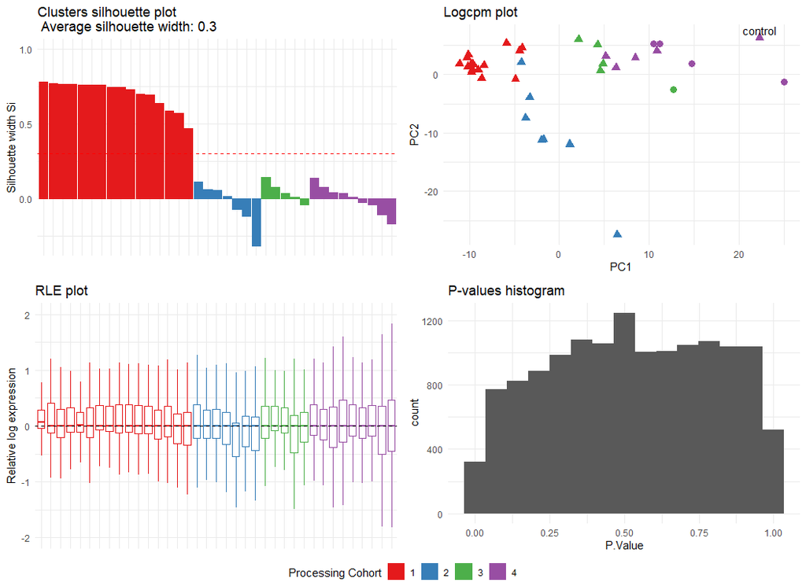

### pDC

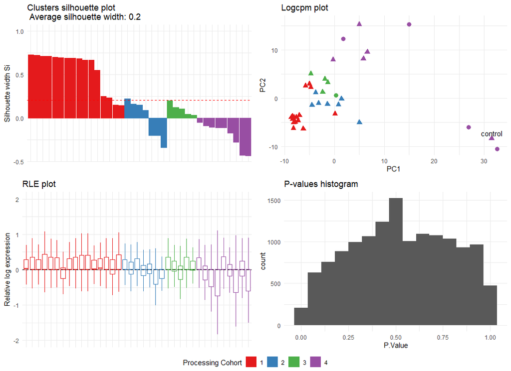

## Removing the Processing Cohort effect

we attempted to estimate the processing cohort effect directly and subtract it from the data in order to reduce technical variation. However, this approach alone can actually introduce technical noise in the genes where there was no strong processing cohort effect. As a result we have worse PCA and RLE plots for most cell types.

### B

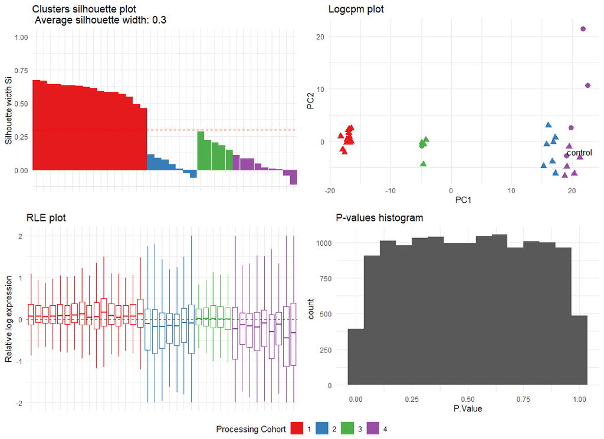

### NK

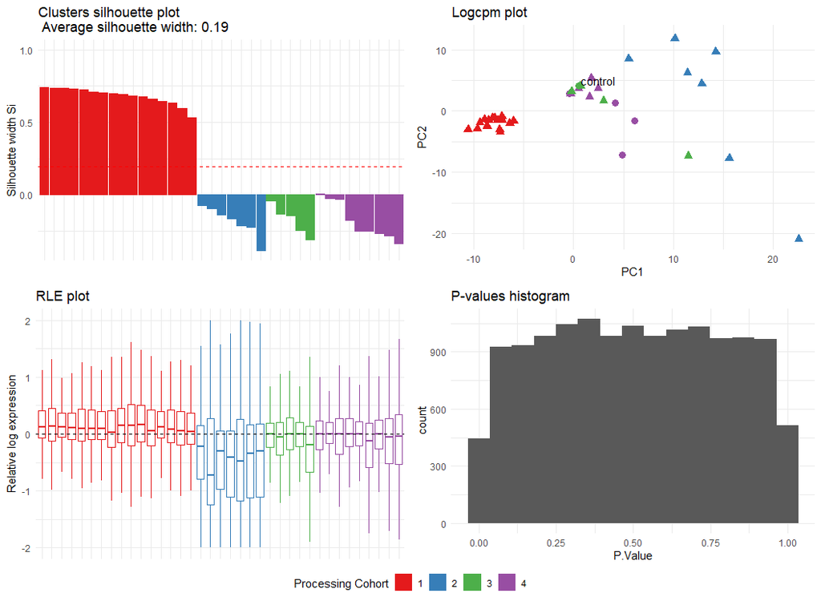

### T4

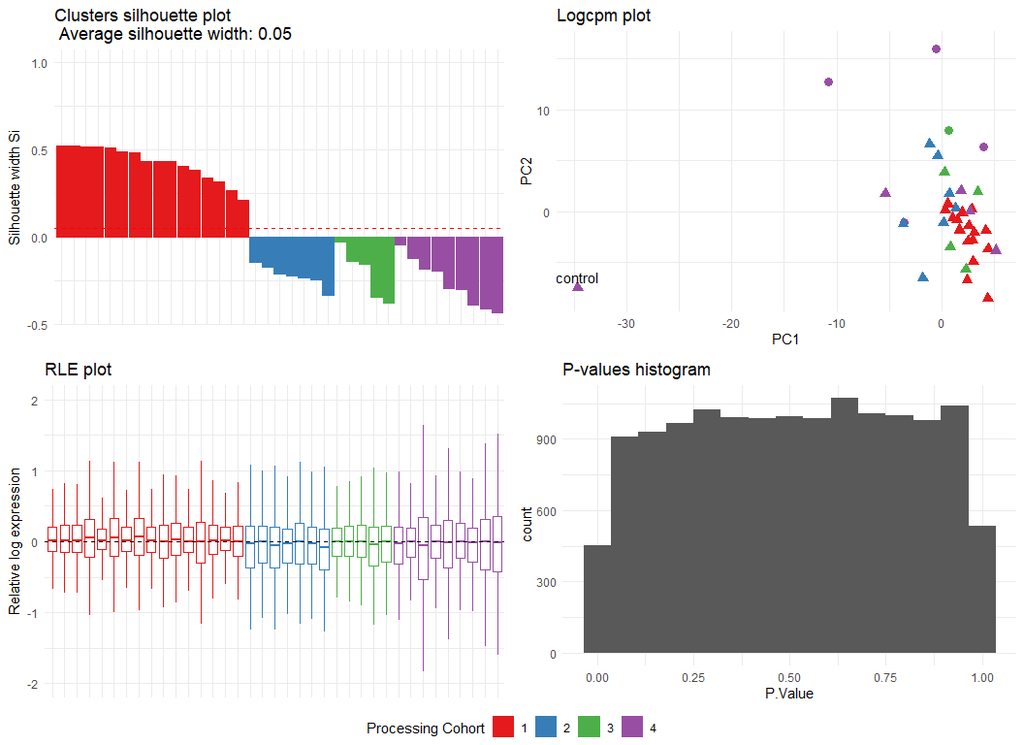

### T8

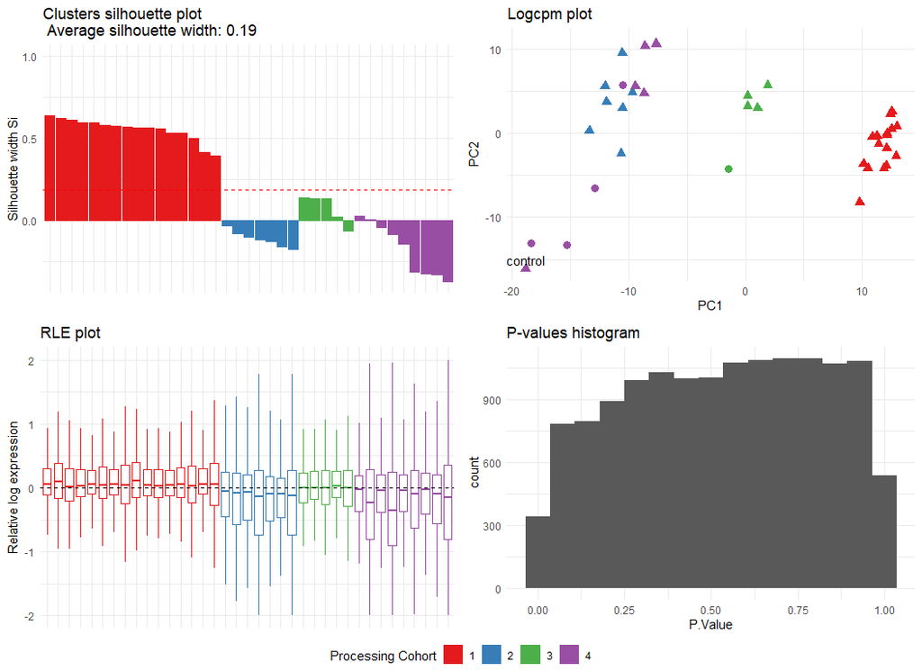

### cDC

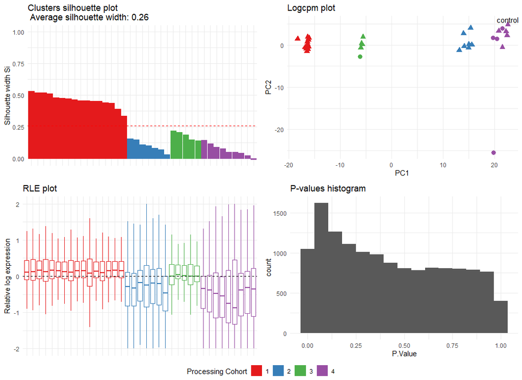

### cM

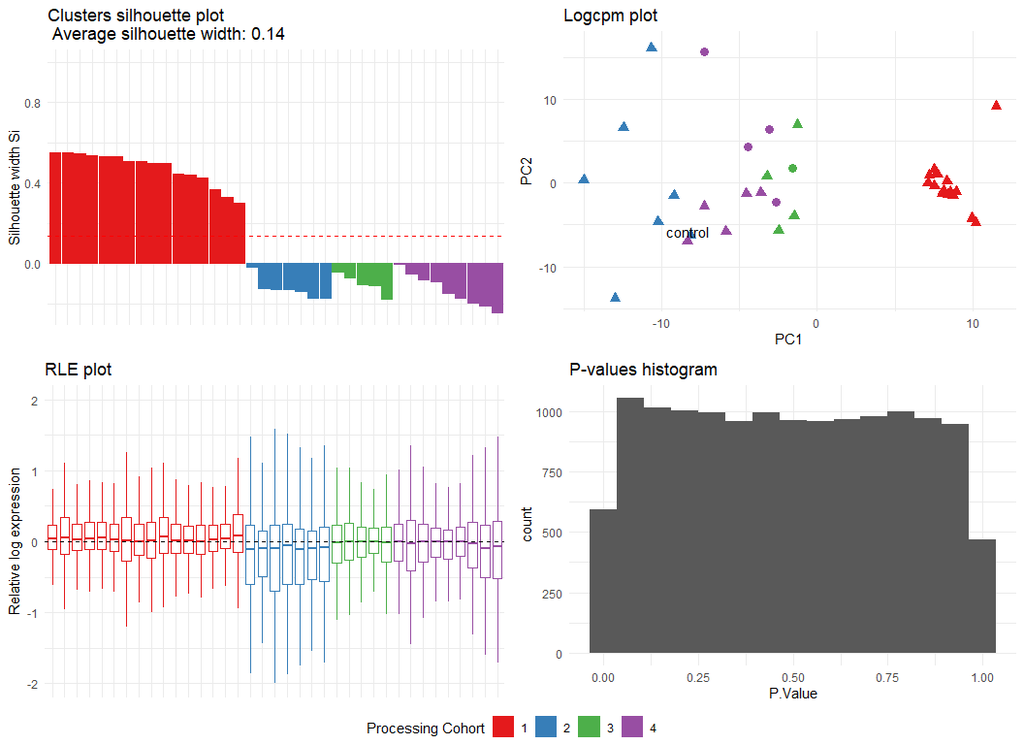

### ncM

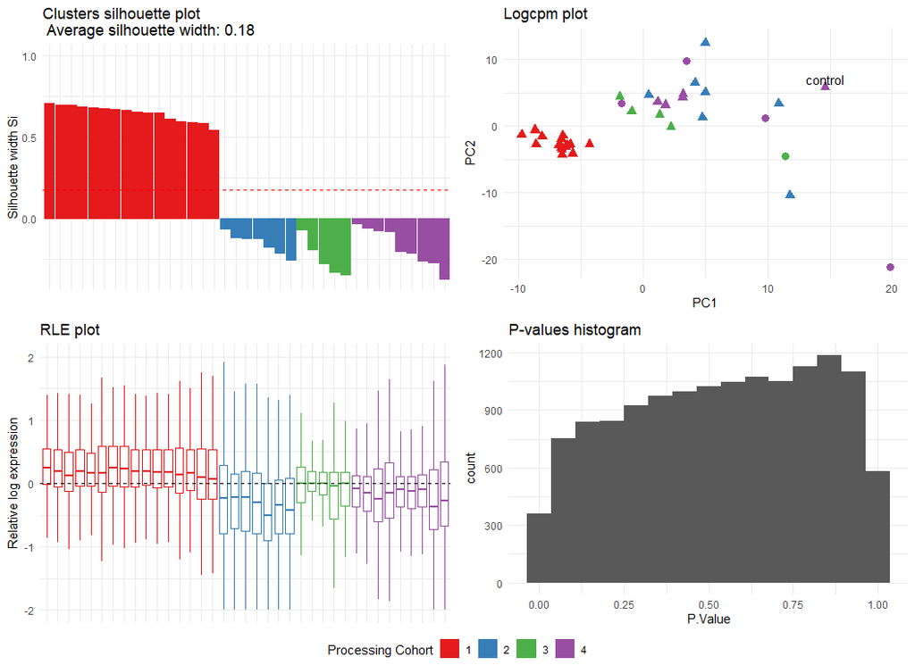

### pDC

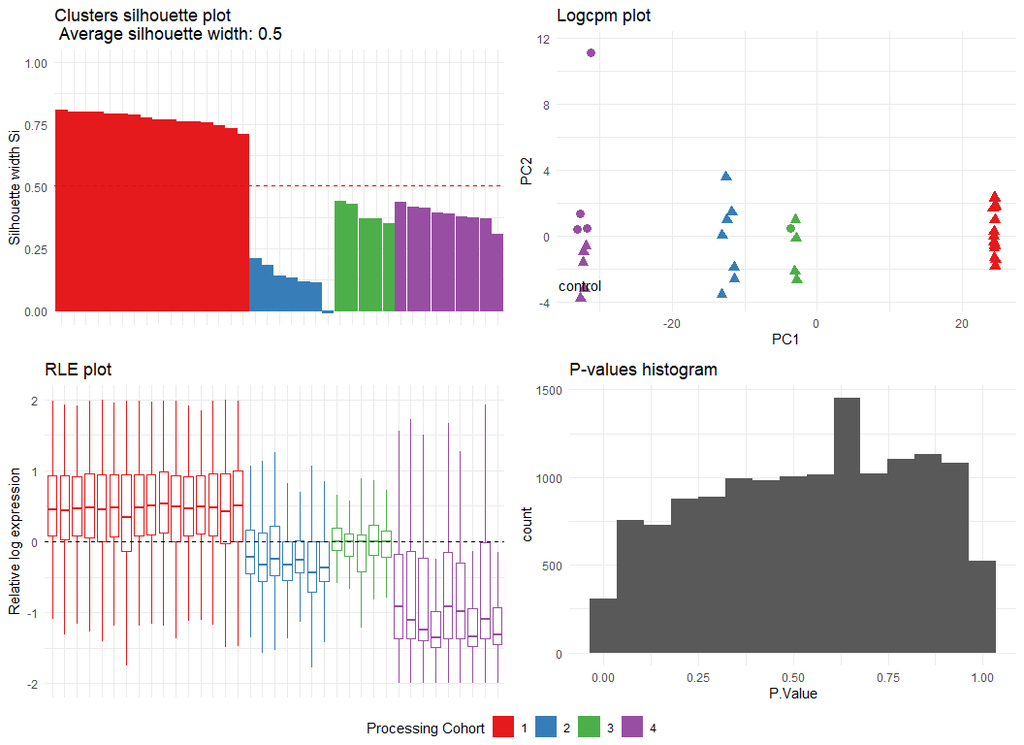

## RUV methods

All RUV methods estimate 5 unwanted factors to capture the unwanted variation in the data, associated for instance with the processing cohort.

### RUV2

The RUV2 method uses solely the negative control genes to estimate the unwanted factors via EFA, for a more detail explanation check the *[technical report](https://statistics.berkeley.edu/tech-reports/820)* from *Gagnon-Bartsch et. al.*.

Here we observe a lower average silhouette coefficient (but not bellow 0), and similar distributions in the RLE plots, indicating the removal of the technical noise associated with the processing cohorts. One issue observed with RUV2 was its inability to properly normalize the control sample, which resulted in it appearing as an outlier in the PCA plots of some cell types. This suggests that the method still has room for improvement.

```r
for (i in 1:length(celltypes)){

  cat(knitr::knit_expand(text=paste0('\n#### ',celltypes[i], ' {-}\n')))

  plots <- list(SilplotsT22[[i]], PCAplotsT22[[i]], RLEplotsT22[[i]], HistsT22[[i]])

  print(ggpubr::ggarrange(plotlist=plots,nrow=2,ncol=2, common.legend = T, legend="bottom"))

  cat(knitr::knit_expand(text=paste0("\n\n")))

}
```

#### B

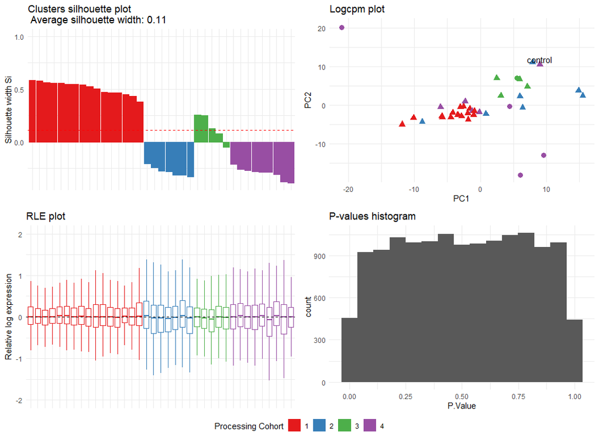

#### NK

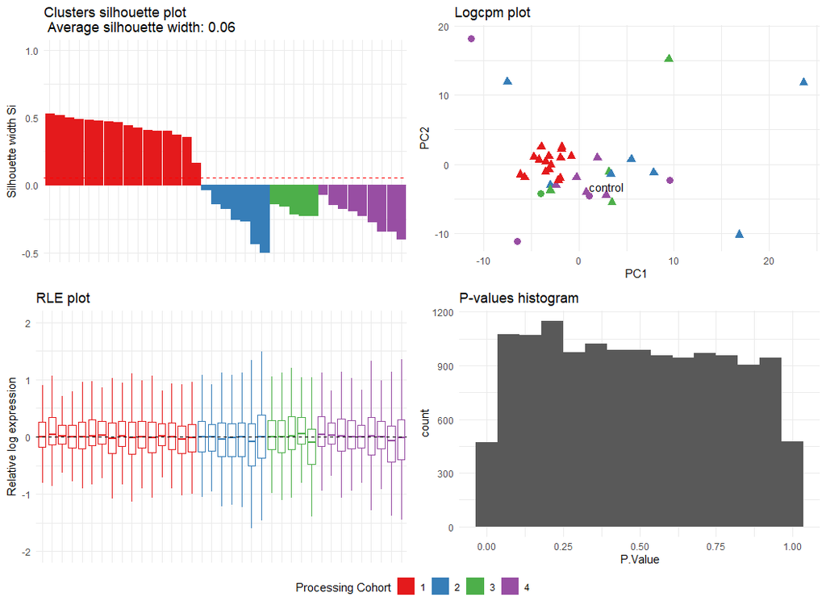

#### T4

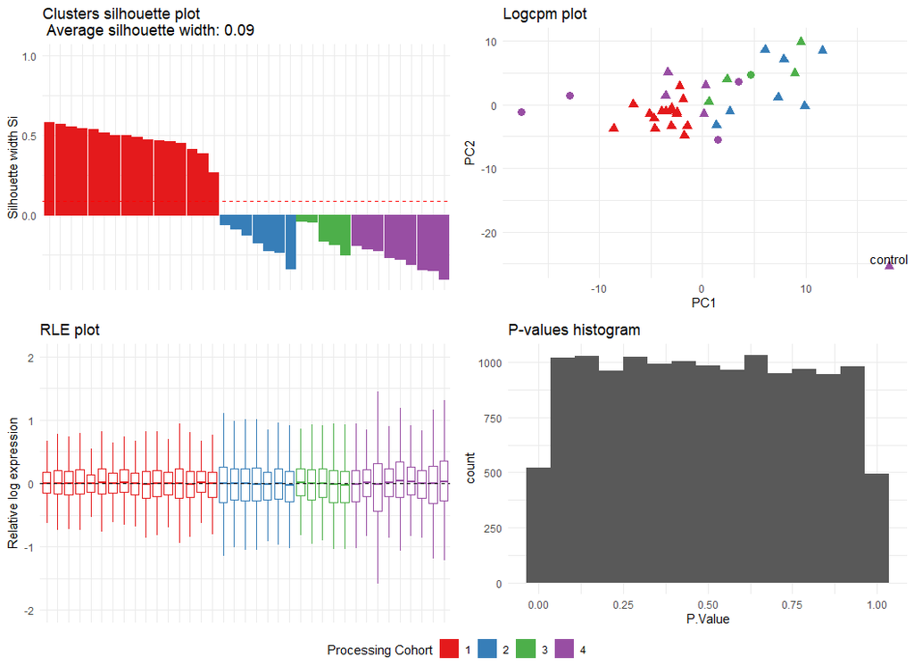

#### T8

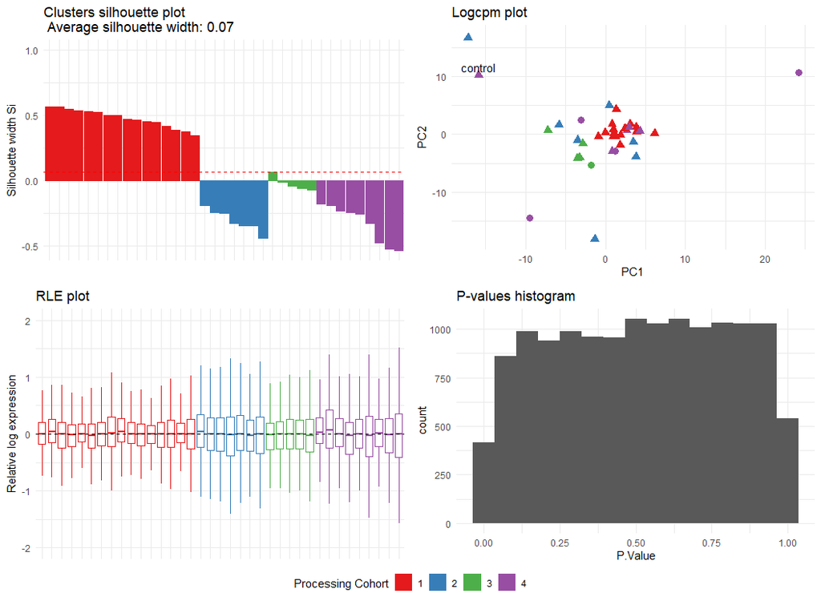

#### cDC

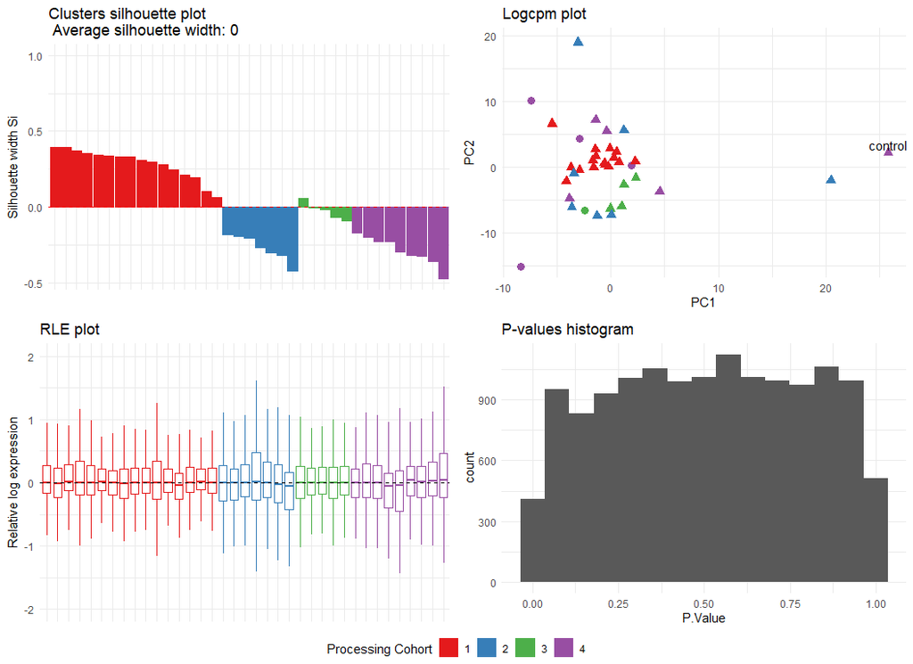

#### cM

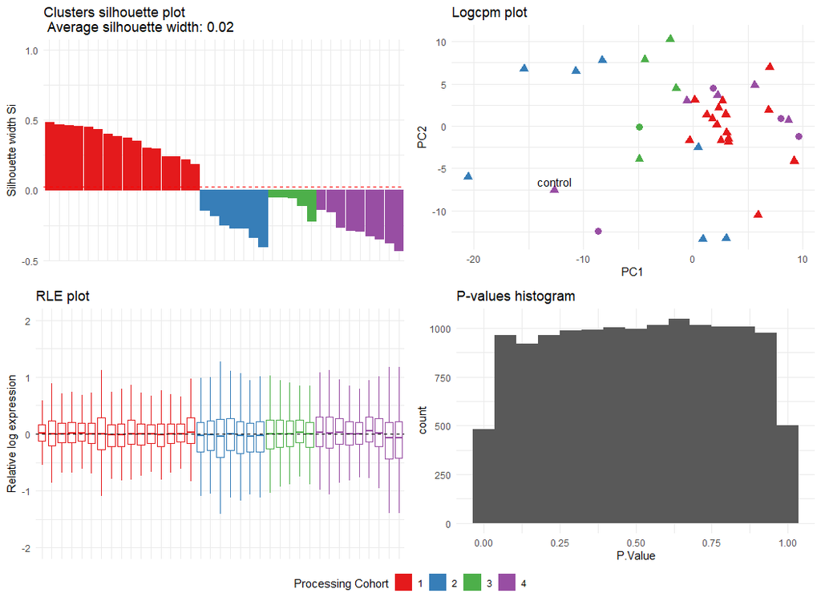

#### ncM

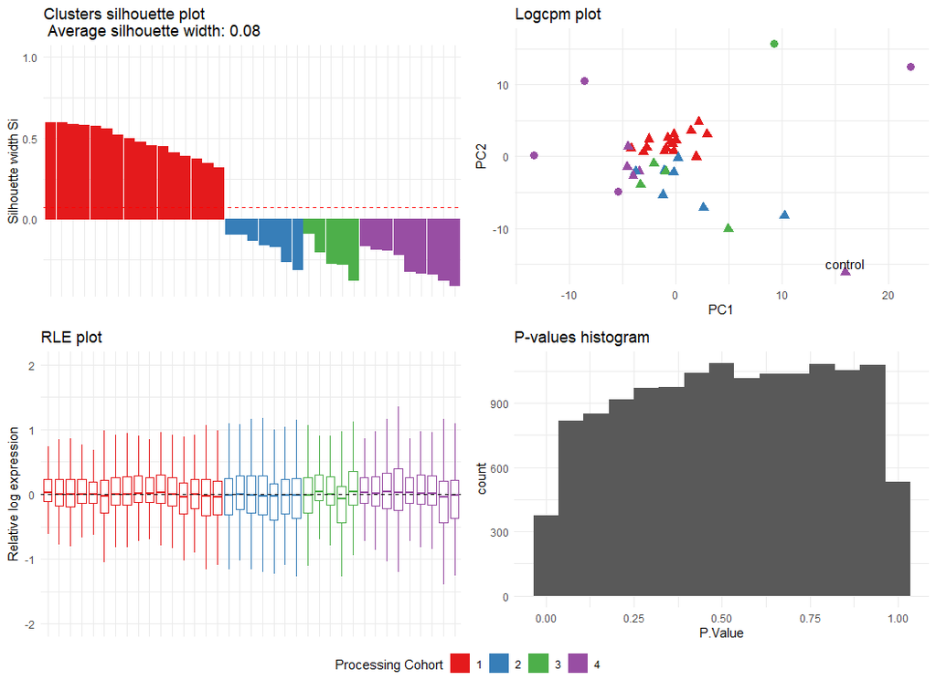

#### pDC

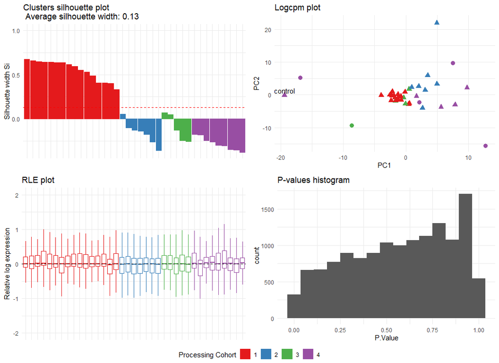

### RUVIII

The RUVIII method uses both negative control genes and negative control samples to estimate the unwanted factors via EFA, for a more detail explanation check the *[original paper](https://academic.oup.com/nar/article/47/12/6073/5494770?login=false)* from *Molania et. al.*.

The dataset has technical replicates mostly between the processing cohorts 2 and 3, therefore it was expected to observe the removal of technical noise mainly between those two sets. Therefore the inclusion of PBPS is relevant to capture the technical noise from all processing cohorts.

#### B

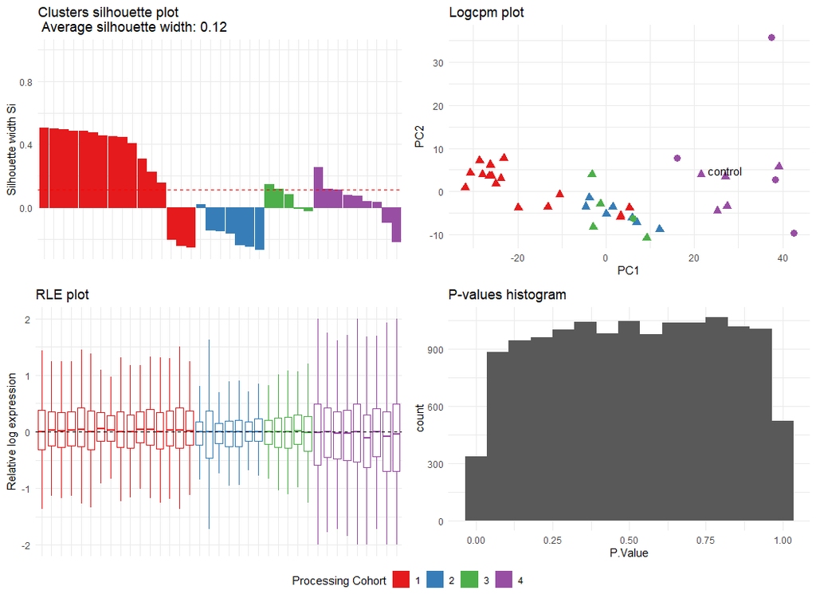

#### NK

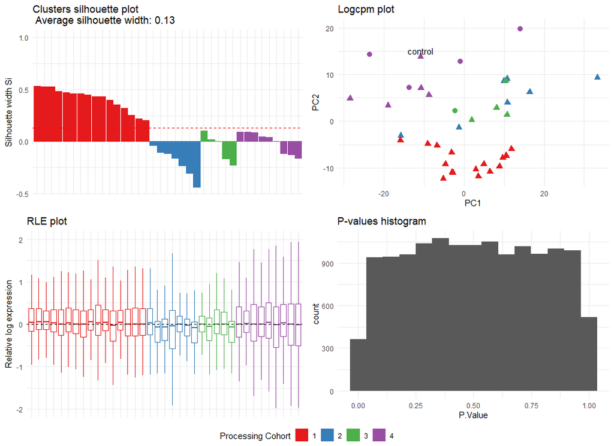

#### T4

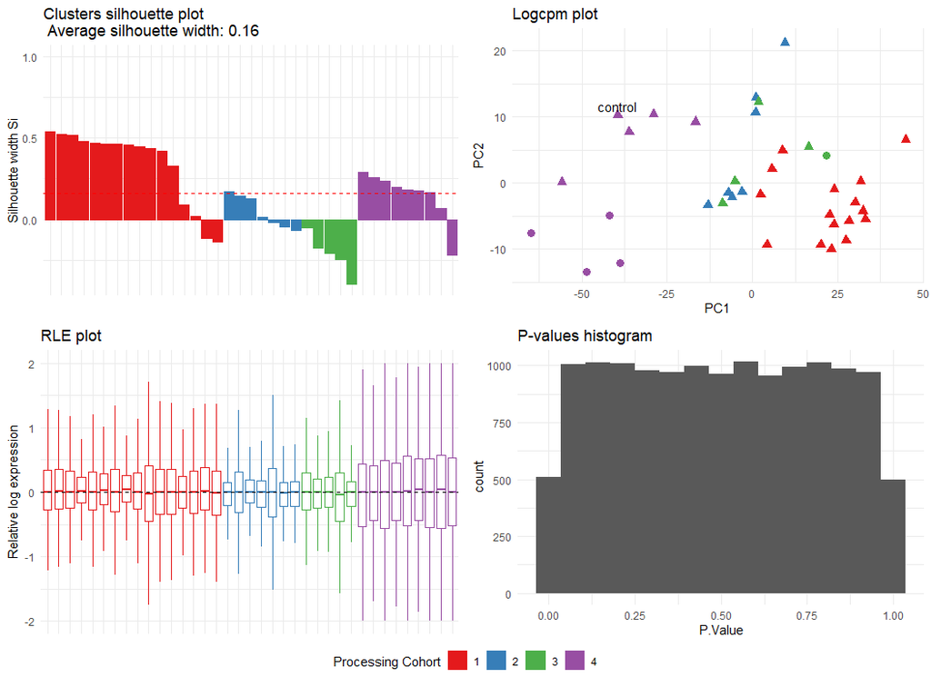

#### T8

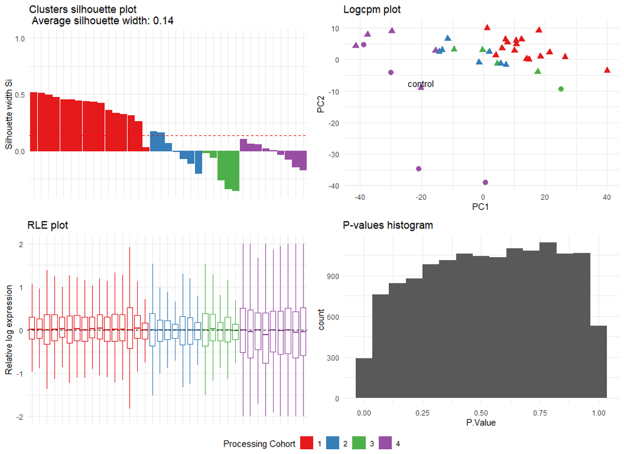

#### cDC

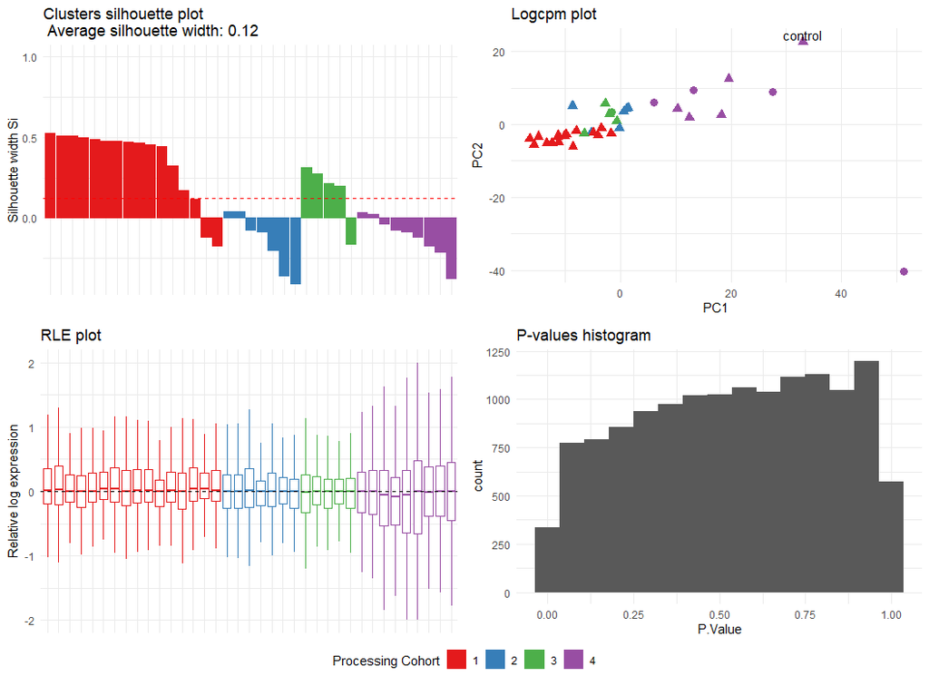

#### cM

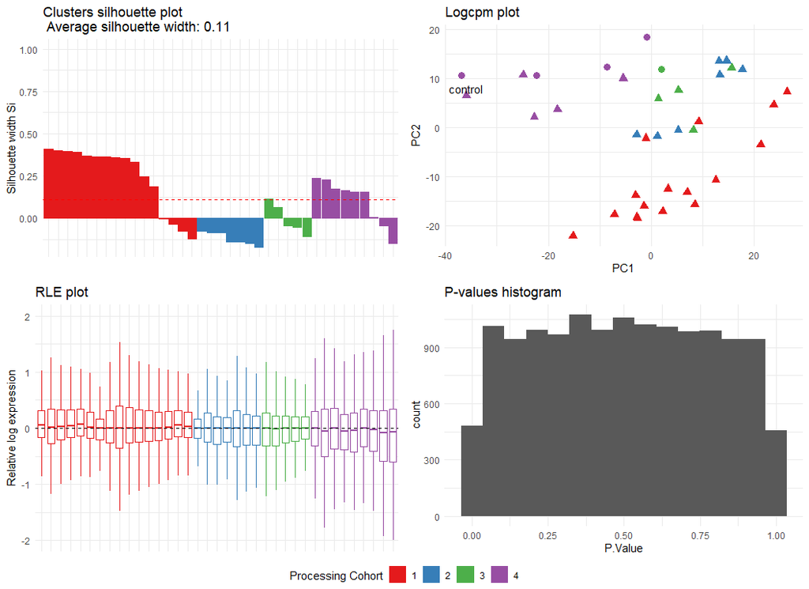